# Forecasting Anomalies in AtHub’s Stock Behavior

Data-Driven Detection of Local Peaks and Dips

Project description

Author

Affiliation

Annabelle Zhu

College of Information Science, University of Arizona

# Proposal

This project proposes the development of an interpretable machine learning model for forecasting short-term volatility anomalies in the Chinese equity market, using AtHub (603881.SH) as a case study. AtHub is a data center infrastructure provider whose stock demonstrates unusually high daily volatility and frequent sensitivity to external events such as government policy announcements (Lin et al. 2024). Rather than predicting stock prices directly—a notoriously noisy and non-stationary target—this study focuses on detecting next-day abnormal price or volume events, defined as daily returns exceeding ±5% or volume spikes greater than 2× the rolling average.

This proposal reflects a practical and scalable approach to market anomaly detection, especially relevant for traders and risk managers seeking data-driven early warning systems.

# High-Level Goal

To develop a machine learning classifier that predicts next-day abnormal volatility events in AtHub (603881.SH) stock using technical analysis (TA) indicators, with anomalies defined as price movements exceeding ±5% or volume surges >2× the 30-day average.

# Dataset

|  | Unnamed: 0 | ts_code | open | high | low | close | pct_chg | vol | amount | volume_obv | ... | trend_adx_neg | momentum_rsi | momentum_wr | momentum_roc | momentum_ao | momentum_ppo_hist | trend_cci | trend_aroon_up | trend_aroon_down | trend_aroon_ind |
| --- | --- | --- | --- | --- | --- | --- | --- | --- | --- | --- | --- | --- | --- | --- | --- | --- | --- | --- | --- | --- | --- |
| 0 | 0 | 603881.SH | 26.78 | 26.80 | 26.31 | 26.42 | -1.7479 | 274104.38 | 725328.815 | 274104.38 | ... | 0.0 | 100.0 | -77.551020 | 0.0 | 0.0 | 0.000000 | 0.000000 | 0.0 | 0.0 | 0.0 |
| 1 | 1 | 603881.SH | 26.81 | 26.95 | 26.50 | 26.89 | -0.5547 | 328799.42 | 879021.084 | 602903.80 | ... | 0.0 | 100.0 | -9.375000 | 0.0 | 0.0 | 0.113379 | 66.666667 | 4.0 | 0.0 | 4.0 |
| 2 | 2 | 603881.SH | 27.77 | 27.99 | 27.02 | 27.04 | -2.8387 | 453556.90 | 1240793.683 | 1056460.70 | ... | 0.0 | 100.0 | -56.547619 | 0.0 | 0.0 | 0.214038 | 100.000000 | 8.0 | 0.0 | 8.0 |
| 3 | 3 | 603881.SH | 27.81 | 27.98 | 27.38 | 27.83 | -0.8550 | 438206.80 | 1214125.954 | 1494667.50 | ... | 0.0 | 100.0 | -9.523810 | 0.0 | 0.0 | 0.453638 | 94.972067 | 8.0 | 0.0 | 8.0 |
| 4 | 4 | 603881.SH | 28.30 | 28.86 | 27.56 | 28.07 | 0.2858 | 694568.92 | 1954292.549 | 2189236.42 | ... | 0.0 | 100.0 | -30.980392 | 0.0 | 0.0 | 0.633289 | 107.892527 | 16.0 | 0.0 | 16.0 |

5 rows × 32 columns

## Dataset info

```
'Dataset contains 375 rows and 32 columns.'
```

```
<class 'pandas.core.frame.DataFrame'>
RangeIndex: 375 entries, 0 to 374
Data columns (total 32 columns):
 #   Column             Non-Null Count  Dtype
---  ------             --------------  -----
 0   Unnamed: 0         375 non-null    int64
 1   ts_code            375 non-null    object
 2   open               375 non-null    float64
 3   high               375 non-null    float64
 4   low                375 non-null    float64
 5   close              375 non-null    float64
 6   pct_chg            375 non-null    float64
 7   vol                375 non-null    float64
 8   amount             375 non-null    float64
 9   volume_obv         375 non-null    float64
```

[output cut: 24 more lines]

## Target `Anomalies`

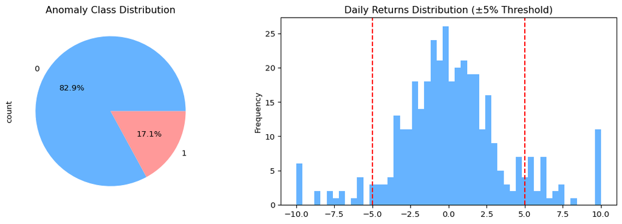

Distribution of Anomaly Labels (Target Variable)

## Feature Construction Strategy

- **Momentum** (e.g., RSI, MACD, Williams %R): capture price velocity and potential reversals.
- **Volume-based** (e.g., OBV, MFI, VPT): track accumulation/distribution behavior.
- **Volatility** (e.g., ATR, Bollinger Band Width, Ulcer Index): quantify market turbulence.
- **Trend strength** (e.g., ADX, Aroon, CCI): detect the emergence or weakening of price trends.

These indicators were computed using the `tsta` Python library and merged with daily OHLCV data. We conducted correlation analysis to filter redundant signals and retain complementary ones, as illustrated in the figure below.

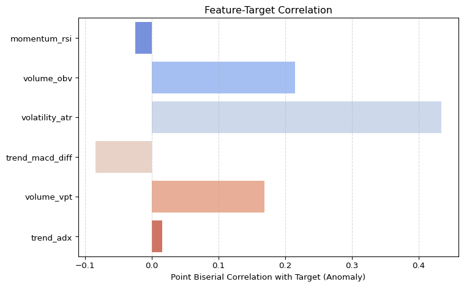

Correlation Between Features and Target (Anomaly)

This engineered feature space provides interpretable signals that are sensitive to both directional shifts and liquidity changes—two major components in anomaly formation.

## Model Development Approach

### Data Splitting Strategy

Given the time-series nature of stock data, we implement: - **Chronological split**: First 80% for training, last 20% for testing - **Walk-forward validation**: Expanding window cross-validation

### Evaluation Metrics

We prioritize: - **Recall**: Minimizing false negatives (missed anomalies) - **F1-score**: Balancing precision/recall - **Matthews Correlation Coefficient**: Robust to class imbalance

### Baseline Models

| Model | Strengths | Weaknesses |
| --- | --- | --- |
| **XGBoost** | Handles nonlinear relationships | Requires careful tuning |
| **LightGBM** | Efficient with large features | Sensitive to outliers |
| **Logistic Regression** | Interpretable coefficients | Limited nonlinear capacity |

# Dataset Summary

The dataset is sourced via the **Tushare API** and engineered using Python’s `tsta` technical indicator library. It includes:

- **375 daily records** of AtHub stock trading from the past ~18 months
- **32 columns**, including:
  - **Price data**: `open`, `high`, `low`, `close`, `pct_chg`
  - **Volume metrics**: `vol`, `amount`, `volume_obv`, `volume_cmf`, `volume_vpt`, `volume_vwap`, `volume_mfi`
  - **Volatility indicators**: `volatility_bbw`, `volatility_atr`, `volatility_ui`
  - **Trend & momentum indicators**: `trend_macd`, `trend_adx`, `momentum_rsi`, `momentum_wr`, `momentum_roc`, `trend_aroon_up`, etc.

This feature-rich time series provides a robust foundation for testing anomaly detection models under realistic, noisy conditions.

# Motivation & Goals

**Why AtHub (603881.SH)?** AtHub is a leading Chinese data center infrastructure provider whose stock exhibits unusually high short-term volatility, making it a strong candidate for anomaly-based forecasting. Over the past six months, its daily return volatility (σ ≈ 35%) has far exceeded the industry average (≈ 22%). Moreover, its price reacts sharply to regulatory announcements and policy shifts, reflecting its sensitivity to macro-level and sector-specific events.

SHAP analysis is integrated to uncover feature interactions that precede volatility (e.g., “high RSI + declining OBV” may precede reversals), offering not just predictive power but also interpretability.

# Questions

- Q1. Can TA features detect anomalies 1–3 days in advance? Which indicators lead?
- Q2. Which features drive predictions? Do they align with financial theory?
- Q3. How do anomaly thresholds (±3% vs. ±5% vs. ±7% price; 1.8x vs. 2.5x volume) impact model performance?

# Analysis plan

Here’s a refined **weekly plan** in bullet-point format that incorporates EDA before feature engineering, aligns with your research questions, and includes all required deliverables (write-up, presentation, website). Tools are listed separately for clarity:

## **Weekly Plan: Predicting Abnormal Volatility in AtHub (603881.SH)**

#### **Week 1: Data Collection & Exploratory Analysis (EDA)**

- **Tasks**:
  - Collect 1+ year of OHLCV data for AtHub using Tushare API.
  - Generate TA features (momentum, volume, volatility, trend indicators).
  - Perform EDA:
    - Visualize price/volume trends and anomaly frequency.
    - Check for missing data, outliers, and stationarity.
    - Analyze correlation between raw price/volume metrics.
  - Define preliminary anomaly thresholds (±5% returns, 2× volume).
- **Tools**: `tushare`, `pandas`, `matplotlib`, `ta`, `seaborn`.

#### **Week 2: Feature Engineering & Baseline Model**

- **Tasks**:
  - Refine anomaly labels based on EDA insights.
  - Split data chronologically (e.g., 80% train, 20% test).
  - Train baseline models (XGBoost/LightGBM) and evaluate with accuracy/F1.
- **Research Questions Addressed**:
  - *Q3 (Threshold Impact)*: Test initial thresholds.
- **Tools**: `scikit-learn`, `xgboost`.

#### **Week 3: Model Tuning & Interpretability**

- **Tasks**:
  - Optimize hyperparameters using time-series cross-validation.
  - Compare performance across thresholds (±3%, ±5%, ±7%).
  - Apply SHAP to identify top predictive features and patterns.
  - Test feature lead times (1–3 days pre-anomaly).
- **Research Questions Addressed**:
  - *Q1 (Predictive Horizon)*: Lag feature analysis.
  - *Q2 (Feature Importance)*: SHAP/partial dependence plots.
- **Tools**: `optuna`, `shap`, `statsmodels` (Granger causality).

#### **Week 4: Final Evaluation & Deliverables**

- **Tasks**:
  - **Write-up (1,000–2,000 words)**:
    - Introduction, Methods, Results (SHAP plots, threshold analysis), Conclusion.
  - **Presentation (5 mins)**:
    - Quarto slides covering motivation, methods, key findings, Q&A prep.
  - **Website**:
    - Host report, code, and interactive visualizations (e.g., Plotly dashboards).
  - **Repo Organization**:
    - Logical structure (e.g., `data/`, `notebooks/`, `results/`).
    - Clear `index.qmd` as entry point.
- **Tools**: Quarto, `plotly`, `pkgdown`

# Expected Outcomes

1. **Threshold Analysis Results**:
   - Precision-recall curves for ±3%/±5%/±7% thresholds
   - Optimal threshold selection based on trading costs
2. **Top Predictive Features**:
   - SHAP summary plot of top 10 influential indicators
   - Temporal importance patterns (e.g., volume leads price)
3. **Practical Trading Rules**:
   - Actionable signals like:  
     *“When RSI > 70 AND OBV < 30-day average → 67% probability of next-day drop >5%”*
4. **Interactive Dashboard**:
   - Dynamic visualization of anomaly predictions
   - Threshold adjustment interface

# Reference

林竑皓, 唐海清, 王奕红, & 缪欣君. (2024年12月18日). 数据港（603881）：国有数据中心龙头，整体经营稳步向上 [公司研究报告]. 天风证券. https://www.tfzq.com

## References

Lin, Honghao, Haiqing Tang, Yihong Wang, and Xinjun Miao. 2024. “数据港（603881）：国有数据中心龙头，整体经营稳步向上.” 天风证券. https://www.tfzq.com.